# Class Topics Covered

2023-01-17

### A few words of wisdom

- File extensions don’t actually mean anything. A .csv file doesn’t *have* to be comma-separated values. A .txt file could actually be a gzipped fasta.
- Use relative file paths whenever possible. Each project has its own directory and file paths start from there.
- There are usually 50 ways to accomplish the same task. There is no ‘right way’ as long as it works, is consistent, and is reproducible.
- File/Dir names **NEVER** have spaces in them. File names should be useful to both you and the code you write. You should use a naming system that can be *programmatically* accessed.
  - `sample_01_R1.fasta` is a good name
  - `Sample1R1.fasta` is a bad name
  - `sample 1 forwardreads.fasta` is unacceptable and will get you kicked out of class

### Bash programs

| bash_programs | purpose | info |
| --- | --- | --- |
| pwd | where am I? | https://ss64.com/bash/pwd.html |
| ls | what stuff is here? | https://ss64.com/bash/ls.html |
| cd | change directory <path> | https://ss64.com/bash/cd.html |
| cat | stick stuff together and print to screen | https://ss64.com/bash/cat.html |
| touch | reset timestamp / make empty file | https://ss64.com/bash/touch.html |
| nano | bash text editor | https://www.howtogeek.com/howto/42980/the-beginners-guide-to-nano-the-linux-command-line-text-editor/ |
| cp | copy <from> <to> | https://ss64.com/bash/cp.html |
| mv | move <from> <to> | https://ss64.com/bash/mv.html |
| rm | remove FOREVER | https://ss64.com/bash/rm.html |
| cut | pick fields (columns) -f field #s -d delimiter | https://ss64.com/bash/cut.html |
| grep | find lines in a file that match a pattern | https://ss64.com/bash/grep.html |
| wget | pull a file from a URL and save it as a file locally | https://linuxize.com/post/wget-command-examples/ |
| sed | streaming editor | https://www.tutorialspoint.com/sed/sed_quick_guide.htm |
| mkdir | make new directory | https://man7.org/linux/man-pages/man1/mkdir.1.html |

### Project structure

Every project you work on should strive to be self-contained. It should also document itself.

- README file to explain project motivation, data sources, hypotheses, *etc.*
- Workflow file that documents EVERYTHING that you’ve done, from acquiring raw data through all processing/analysis steps
- Data should live inside the project (if not using cloud solutions)
- File names should be intuitive and programmatic

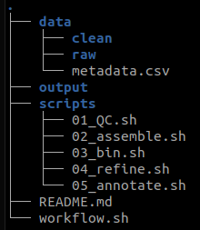

### Special characters in Bash

**See [this link](https://mywiki.wooledge.org/BashGuide/SpecialCharacters) for a list of special characters.**

If any file name or pattern you’re trying to match contains one of these characters and you want it to be interpreted literally, you need to include a back-slash right in front of the character.

For example, the file `Sample 1.fasta` has a space. That’s a special character! So to point to this file in a script, you would have to specify `Sample\ 1.fasta` which interprets the space as literally just a space character instead of its special meaning.

If your search string includes a back-slash for some insane but likely reason, you’d have to escape it as well: `File\1.fasta` can only be addressed as `File\\1.fasta`

### Manipulating ‘streams’

**All terminal information is text-based and flows through 3 main ‘streams.’ These streams have names and numbers:**

- <stdin>
- <stdout>
- <stderr>

(You can have other streams, but only need them in special scenarios)

**<stdin>** The input text. Can come from keyboard entry, a file, or another program. This is what is typically fed into a program. AKA: **0>**

**<stdout>** The output from a program. Typical default is to send it to the terminal screen. AKA: **1>**

**<stderr>** The error info (if it exists). AKA: **2>**

**Streams can be redirected in various ways to make them more useful.**

**>** This redirects the <stdout> to a file (overwrites any existing file). Equivalent to **1>**

**>>** This redirects the <stdout> to a file (appends to bottom of any existing file). Equivalent to **1>>**

**|** This redirects the <stdout> to a program. You can chain together many programs to process subsequent outputs in turn… a pipeline.

**2>** This redirects the <stderr> to a file (overwrites)

**3>** This redirects the <a-third-secret-stream> to a file (overwrites)

### Wildcards and pattern matching

These wildcards and special patterns ARE DIFFERENT FROM standard Bash special characters and they are used in **Regular Expressions** for pattern matching…

| symbol | meaning |
| --- | --- |
| * | matches 0 to infinite of ANYTHING |
| ? or . depending on regex flavor | matches up to one instance of any character |
| [1,2,3] | matches exactly one instance of 1, 2, OR 3 |
| x{4} | the preceding character will be matched exactly 4 times |
| ^ | matches BEGINNING OF LINE |
| [^a] | matches any character EXCEPT ‘a’ |
| $ | matches END OF LINE |
| \ | ‘escape character’ any special character will be interpreted literally instead of its special meaning |

### File paths vs $PATH

In Bash, $ denotes ‘the value of a variable’

Thus, you have a variable named PATH, and $PATH is the literal contents of that variable. Your $PATH contains a colon-separated list of paths (locations) in your computer that Bash automatically knows about. Any programs (like ls, grep, etc.) that live somewhere in your $PATH can be executed from anywhere on your computer.

If you want to be able to call up a program like seqtk, once you download it, you need to either move it into an existing PATH directory, or add its location to your $PATH.

**If you want to add a new directory to your PATH:** [See here](https://linuxize.com/post/how-to-add-directory-to-path-in-linux/)

### Fasta and Fastq files

**Fasta** (*usually* denoted by .fna .fa .fasta extension)

These *ought* to follow a consistent every-other-line format, but in practice sometimes the sequence lines are split over several lines… because life isn’t fair

>name

Sequence

**Fastq** (*usually* denoted by .fnq .fq .fastq extension)

These *ought* to follow a standard every-four-lines pattern.

@name

sequence

+

quality scores

Quality score interpretation:

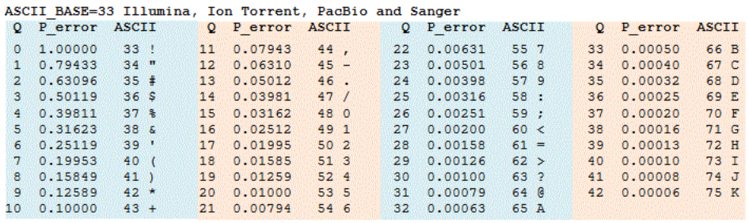

The fact that sequence header (names) lines start with ‘@’ paired with the fact that ‘@’ is a valid quality score makes counting sequences more difficult than with a fasta file.

### Programs we’ve installed

[**seqtk**](https://github.com/lh3/seqtk) – This “sequence toolkit” contains a crapload of useful stuff for working with fasta and fastq files

### Nifty things

`import newimage.png` (Gives a screenshot tool)